# MB5370 Module 1: Introduction to Programming

Katya Jagolta

2023-02-22

Workspace: ~/MB5370 Techniques in Mar Sci 1/Module_01.R

# Workshop 1

### 2.3.6 Getting started

Simple math:

```r
2+1
```

```
## [1] 3
```

Returns a sequence of numbers from 1 to 30:

```r
1:30
```

```
##  [1]  1  2  3  4  5  6  7  8  9 10 11 12 13 14 15 16 17 18 19 20 21 22 23 24 25
## [26] 26 27 28 29 30
```

### 2.3.7 Variables, objects, and assignment

Assigning my age, my name, and then some simple math with age:

```r
age <- 26
first_name <- 'Katya'
age + 1
```

```
## [1] 27
```

```r
age + age
```

```
## [1] 52
```

Errors: Names can’t start with a number and can’t include special symbols or spaces! (Made the following code comments in order to knit)

```r
# Errors
# 01_age <- 26
# !_age <- 26
# age katya <- 26
```

Uppercase vs. lowercase makes a difference:

```r
Age <- 45
age
```

```
## [1] 26
```

```r
Age
```

```
## [1] 45
```

Exercise: sum numbers.

1. Add up numbers and assign to a name.
2. Name another number.
3. Add both together.

```r
apple <- 15+25.1+20.25
banana <- 17
apple + banana
```

```
## [1] 77.35
```

### 2.3.9 Built-in functions.

1. Assign the value 26.7 to years_old.
2. Round up.
3. Round down.

```r
years_old <- 26.7
round(years_old)
```

```
## [1] 27
```

```r
floor(years_old)
```

```
## [1] 26
```

```r
name <- "Katya"
years_old <- 26.765
round(years_old, 2)
```

```
## [1] 26.76
```

```r
paste(name, "is", floor(years_old), "years old.")
```

```
## [1] "Katya is 26 years old."
```

### 2.3.10 Debugging

Misconceptions: Value of total is a spreadsheet would be 100, but in programming the variable maintains the value it was assigned (65) until reassigned.

```r
grade <- 55
total <- grade + 10
print (total)
```

```
## [1] 65
```

```r
grade <- 90
print (total)
```

```
## [1] 65
```

```r
total <- grade + 10
print (total)
```

```
## [1] 100
```

What will this code do? The printed result should equal 10.

```r
p <- 2
z <- 5
out <- p*z
print (out)
```

```
## [1] 10
```

Error reports:

```r
# out <- p * a
```

Error: object ‘a’ not found (because a is an undefined variable). The following should work because both p and z have already been defined:

```r
out <- p * z
out
```

```
## [1] 10
```

Testing: the following will tell you whether x is a character and then whether it’s numeric.

```r
x <- 1
is.character(x)
```

```
## [1] FALSE
```

```r
is.numeric(x)
```

```
## [1] TRUE
```

Exercise: identify problems in this code…

1. Missing a comma.
2. Misspelled “my_quiz”
3. Function should be length()

```r
# my_quiz <- c("uno",
#             "dos",
#             "tres",
#             "quatro"
#             "cinco")
# print (my_quis)
# str(my_quiz)
# len(my_quiz)
```

Fixed the code and testing it: creates and prints my_quiz, then tells you the data type and the length/number of elements.

```r
my_quiz <- c("uno",
             "dos",
             "tres",
             "quatro",
             "cinco")
print (my_quiz)
```

```
## [1] "uno"    "dos"    "tres"   "quatro" "cinco"
```

```r
str(my_quiz)
```

```
##  chr [1:5] "uno" "dos" "tres" "quatro" "cinco"
```

```r
length(my_quiz)
```

```
## [1] 5
```

### 2.3.11 Data types

Exercise: try to produce the 4 data types (character, numeric, integer, logical)

```r
# Character:
char <- "testing"
class(char)
```

```
## [1] "character"
```

```r
# Numeric:
num <- 7
class(num)
```

```
## [1] "numeric"
```

```r
# Integer:
int <- as.integer(num) # Change num (7) from numeric to an integer
class(int)
```

```
## [1] "integer"
```

```r
# Logical:
log <- FALSE
class(log)
```

```
## [1] "logical"
```

### 2.3.12 Data structures

Creating vectors of numeric elements, character elements, and a list. The final piece of code returns the 3rd element in the vector z.

```r
y <- c(1, 2, 3)
z <- c("Sarah", "Tracy", "Jon")
zz <- c(1, "Sarah", 3, "Jon")
yy <- list(1, "a", TRUE)

class(y)
```

```
## [1] "numeric"
```

```r
class(z)
```

```
## [1] "character"
```

```r
class(zz)
```

```
## [1] "character"
```

```r
class(yy)
```

```
## [1] "list"
```

```r
z[3]
```

```
## [1] "Jon"
```

### 2.3.13 Packages and libraries

Already have ggplot2, tidyr, and dplyr installed.

```r
# install.packages("earthones")
# Unsuccessful! Package ‘earthones’ is not available for this version of R

# install.packages("redlistr")
# Success

# install.packages("terra")
# Success
```

Create a plot: Make data for the x-axis and y-axis, then plot y by x.

```r
x <- c(-1, -0.8, -0.6, -0.4, -0.2, 0, 0.2, 0.4, 0.6, 0.8, 1)
x
```

```
##  [1] -1.0 -0.8 -0.6 -0.4 -0.2  0.0  0.2  0.4  0.6  0.8  1.0
```

```r
y <- x^3
y
```

```
##  [1] -1.000 -0.512 -0.216 -0.064 -0.008  0.000  0.008  0.064  0.216  0.512
## [11]  1.000
```

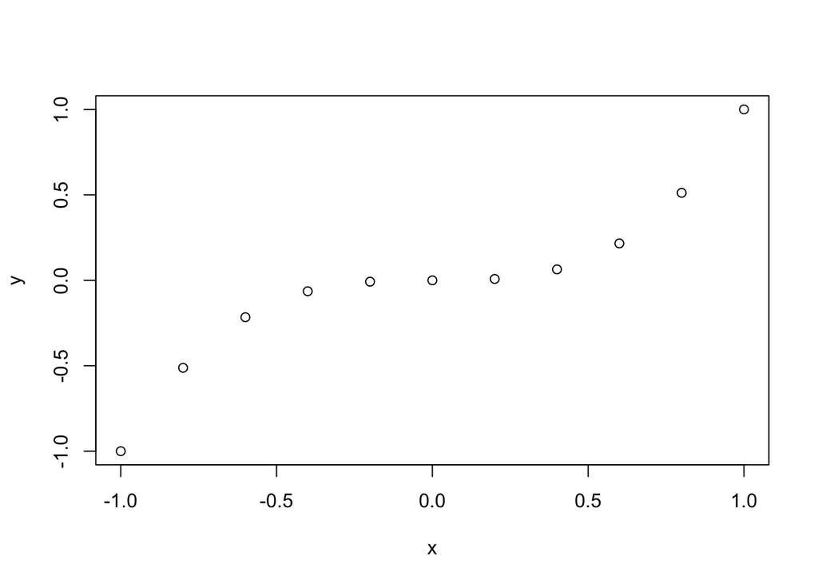

```r
qqplot(x,y)
```

### 2.3.14 Coding best practices

Headers are at top of script along with calling packages ggplot2 and tidyr.

# Workshop 2

### 3.1.1 Learning about for-loops

1. Returns “one run” 4 times, one for each word
2. Returns each of the 4 words
3. Uses “value” instead of “word”; still returns each of the 4 words
4. sys.sleep() suspends execution of R expressions for a specified time interval, in this case 1 second to print each word - helpful if you want to watch & check what your code is doing as it runs.

```r
for (value in c("My", "first", "for", "loop")) { print("one run")
}
```

```
## [1] "one run"
## [1] "one run"
## [1] "one run"
## [1] "one run"
```

```r
for (value in c("My", "second", "for", "loop")) { print(value)
}
```

```
## [1] "My"
## [1] "second"
## [1] "for"
## [1] "loop"
```

```r
for (word in c("My", "third", "for", "loop")) { print(word)
}
```

```
## [1] "My"
## [1] "third"
## [1] "for"
## [1] "loop"
```

```r
for (word in c("My", "fourth", "for", "loop")) { print(word)
  Sys.sleep(1)
}
```

```
## [1] "My"
## [1] "fourth"
## [1] "for"
## [1] "loop"
```

Custom for loop: For i, meaning every single element in my_list, this for loop will print “I am printing loop number i.” and then will say “For loop complete” when it is complete!

```r
my_list <- 1:50
my_list
```

```
##  [1]  1  2  3  4  5  6  7  8  9 10 11 12 13 14 15 16 17 18 19 20 21 22 23 24 25
## [26] 26 27 28 29 30 31 32 33 34 35 36 37 38 39 40 41 42 43 44 45 46 47 48 49 50
```

```r
str(my_list)
```

```
##  int [1:50] 1 2 3 4 5 6 7 8 9 10 ...
```

```r
for (i in my_list) {
  result <- i
  out <- paste("I am printing loop number:", result, ".")
  print(out)
  Sys.sleep(0.6)
}
```

```
## [1] "I am printing loop number: 1 ."
## [1] "I am printing loop number: 2 ."
## [1] "I am printing loop number: 3 ."
## [1] "I am printing loop number: 4 ."
## [1] "I am printing loop number: 5 ."
## [1] "I am printing loop number: 6 ."
## [1] "I am printing loop number: 7 ."
## [1] "I am printing loop number: 8 ."
## [1] "I am printing loop number: 9 ."
## [1] "I am printing loop number: 10 ."
## [1] "I am printing loop number: 11 ."
## [1] "I am printing loop number: 12 ."
## [1] "I am printing loop number: 13 ."
## [1] "I am printing loop number: 14 ."
## [1] "I am printing loop number: 15 ."
```

[output cut: 35 more lines]

```r
print("For loop complete")
```

```
## [1] "For loop complete"
```

Adding a constant outside the loop: For each i, this for loop will print “I am printing loop number (i+500).” and then will say “For loop complete” when it is complete!

```r
add_me <- 500

for (i in my_list) {
  result <- i + add_me
  out <- paste("I am printing loop number:", result, ".")
  print(out)
  Sys.sleep(0.2)
}
```

```
## [1] "I am printing loop number: 501 ."
## [1] "I am printing loop number: 502 ."
## [1] "I am printing loop number: 503 ."
## [1] "I am printing loop number: 504 ."
## [1] "I am printing loop number: 505 ."
## [1] "I am printing loop number: 506 ."
## [1] "I am printing loop number: 507 ."
## [1] "I am printing loop number: 508 ."
## [1] "I am printing loop number: 509 ."
## [1] "I am printing loop number: 510 ."
## [1] "I am printing loop number: 511 ."
## [1] "I am printing loop number: 512 ."
## [1] "I am printing loop number: 513 ."
## [1] "I am printing loop number: 514 ."
## [1] "I am printing loop number: 515 ."
```

[output cut: 35 more lines]

```r
print("For loop complete")
```

```
## [1] "For loop complete"
```

Nested for loop: For each round of the base loop (i), it runs all of the inside loop (j), producing something kind of like an outline in this case (1 abc, 2 abc, 3 abc, etc.).

```r
for (i in c(1,2,3,4,5)) {
  print(paste("I am base loop number: ", i))
  Sys.sleep(0.5)
  for (j in c("a","b","c")) {
    print(paste("... I am inside loop ", j))
  }
}
```

```
## [1] "I am base loop number:  1"
## [1] "... I am inside loop  a"
## [1] "... I am inside loop  b"
## [1] "... I am inside loop  c"
## [1] "I am base loop number:  2"
## [1] "... I am inside loop  a"
## [1] "... I am inside loop  b"
## [1] "... I am inside loop  c"
## [1] "I am base loop number:  3"
## [1] "... I am inside loop  a"
## [1] "... I am inside loop  b"
## [1] "... I am inside loop  c"
## [1] "I am base loop number:  4"
## [1] "... I am inside loop  a"
## [1] "... I am inside loop  b"
## [1] "... I am inside loop  c"
## [1] "I am base loop number:  5"
## [1] "... I am inside loop  a"
## [1] "... I am inside loop  b"
## [1] "... I am inside loop  c"
```

```r
print("Nested loop complete :)")
```

```
## [1] "Nested loop complete :)"
```

Exercise: for loop to list my favorite animals.

```r
numbers <- c(1,2,3,4,5)
animals <- c("tiger shark", "lobster", "blue crab", "shrimp", "cuttlefish")

for (i in numbers) {
  print(paste("My number", i, "favorite animal is a", animals[i]))
}
```

```
## [1] "My number 1 favorite animal is a tiger shark"
## [1] "My number 2 favorite animal is a lobster"
## [1] "My number 3 favorite animal is a blue crab"
## [1] "My number 4 favorite animal is a shrimp"
## [1] "My number 5 favorite animal is a cuttlefish"
```

```r
print("Thanks for coming to my TedTalk!")
```

```
## [1] "Thanks for coming to my TedTalk!"
```

### 3.1.2 If and if-else statements

1. Assigns the value 1 to x.
2. Says if x equals 1, it now equals 2 (reassigns x).
3. Confirming that x now does not equal 1 but equals 2.
4. If x is 1, print “x is: 1”, otherwise print “We’re running the else statement” and then print “x is: 2”.

```r
x <- 1

if (x == 1) {
  x <- 2
}

x == 1
```

```
## [1] FALSE
```

```r
x == 2
```

```
## [1] TRUE
```

```r
if (x == 1) {
  print(paste("x is:", x))
} else {
  print("We're running the else statement")
  print(paste("x is:", x))
}
```

```
## [1] "We're running the else statement"
## [1] "x is: 2"
```

Exercise: make my own if else statement.

1. Says if name is Katya, the last name is Jagolta.
2. Prints my full name, Katya Jagolta.

```r
name <- "Katya"

if (name == "Katya") {
  last_name <- "Jagolta"
}
print(paste(name, last_name))
```

```
## [1] "Katya Jagolta"
```

Changing the name:

1. Says if the name is Katya, the last name is Jagolta; otherwise, the last name is Kenney.
2. Reassigned name to “Kaysha”, so it prints Kaysha Kenney.

```r
name <- "Kaysha"

if (name == "Katya") {
  last_name <- "Jagolta"
} else {
  last_name <- "Kenney"
}
print(paste(name, last_name))
```

```
## [1] "Kaysha Kenney"
```

Changing name back to Katya see what that same if/else statement does: returns the correct name, Katya Jagolta.

```r
name <- "Katya"

if (name == "Katya") {
  last_name <- "Jagolta"
} else {
  last_name <- "Kenney"
}
print(paste(name, last_name))
```

```
## [1] "Katya Jagolta"
```

Adding a new first name without an associated last name:

1. Says if name is Katya, last name is Jagolta; if name is Kaysha, last name is Kenney; otherwise, the last name is unknown.
2. Prints “Kyle… last name is unknown”.

```r
name <- "Kyle"

if (name == "Katya") {
  last_name <- "Jagolta"
} else if (name == "Kaysha"){
  last_name <- "Kenney"
} else {
  last_name <- "... last name is unknown"
}
print(paste(name, last_name))
```

```
## [1] "Kyle ... last name is unknown"
```

### 3.1.3 Functions

1. Formula to convert F to C (but temp_F isn’t defined yet).
2. Convert 100 F to C = 38 C.
3. Convert 200 F to C = 93 C.

```r
# temp_C <- (temp_F - 32) * 5/9
(100-32) * 5/9
```

```
## [1] 37.77778
```

```r
(200-32) * 5/9
```

```
## [1] 93.33333
```

Make a function to convert F to C so we don’t have to type this equation every time, then check that it works correctly:

```r
F_to_C <- function(temp_F){
  temp_C <- (temp_F - 32) * 5/9
  return(temp_C)
}

F_to_C(100)
```

```
## [1] 37.77778
```

```r
F_to_C(200)
```

```
## [1] 93.33333
```

Exercise: write a function to convert celcius to fahrenheit, then test it.

```r
# temp_F <- temp_C * 9/5 + 32

C_to_F <- function(temp_C){
  temp_F <- temp_C * 9/5 + 32
  return(temp_F)
}

C_to_F(0)
```

```
## [1] 32
```

```r
C_to_F(20)
```

```
## [1] 68
```

```r
C_to_F(40)
```

```
## [1] 104
```

### 3.1.4 Data frames

1. Make a dataframe.
2. Check the structure of the dataframe.
3. Convert col1 from numeric to factor (a category rather than a real continuous number).

(Col1 supposed to be factors at the end but still numeric; worked before but not working now, not sure why).

```r
my_dataframe <- data.frame(number = c(1,2,3),
                           name = c("Katya", "Kaysha", "Kyle"),
                           logical = c(TRUE, TRUE, FALSE))
my_dataframe
```

```
##   number   name logical
## 1      1  Katya    TRUE
## 2      2 Kaysha    TRUE
## 3      3   Kyle   FALSE
```

```r
str(my_dataframe)
```

```
## 'data.frame':    3 obs. of  3 variables:
##  $ number : num  1 2 3
##  $ name   : chr  "Katya" "Kaysha" "Kyle"
##  $ logical: logi  TRUE TRUE FALSE
```

```r
as.factor(my_dataframe$no)
```

[output not shown]

```r
str(my_dataframe)
```

```
## 'data.frame':    3 obs. of  3 variables:
##  $ number : num  1 2 3
##  $ name   : chr  "Katya" "Kaysha" "Kyle"
##  $ logical: logi  TRUE TRUE FALSE
```